# PWS_Prioritization

Alene Onion

10/22/2021

## Data set

Here is the joined data set of SDWIS Information joined to waterbody assessments NOTE: ASSESSMENT ARE DRAFT AND MUST NOT BE SHARED OUTSIDE THE DEPARTMENT

Unfortunately, this file was too large to share in this format I will have to email it to you separately

OGR data source with driver: ESRI Shapefile Source: "C:- New York State Office of Information Technology Services_Prioritization_layer“, layer:”pws_10_2021" with 293 features It has 12 fields Integer64 fields read as strings: OBJECTID OGR data source with driver: ESRI Shapefile Source: “C:- New York State Office of Information Technology Services.Database\2020.requests.data.selector”, layer: “dec_wipwl_lakes” with 2096 features It has 27 fields

Filtered to those that are: 1. surface water (‘Primary.Source’) 2. active (‘Facility.Activity’) 3. Permanent (‘Availability.Description’) Other filters to consider: Is.Wholesaler Seller.Treatment.Description (“Filtered”,“Partially treated by seller”,“Not treated” )

## Classification and Assessment

PLEASE NOTE the assessment data are DRAFT from Zach and Sarah and SHOULD NOT BE SHARED outside of the agency.

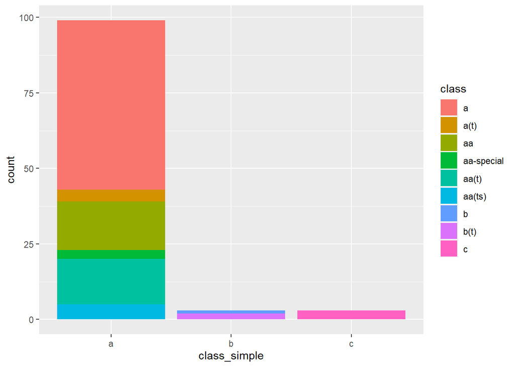

Now remove class B and C waters because we need to table those for now And plot the distribution of assessments for the source_water_supply use ONLY

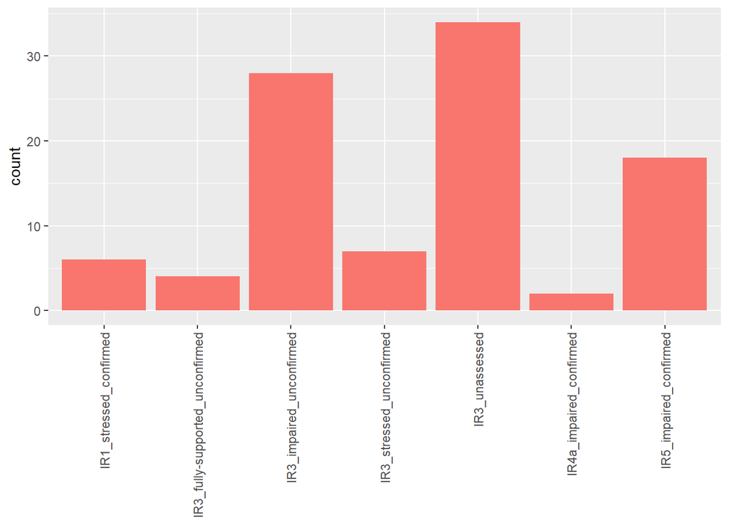

| use_assessment | n |
| --- | --- |
| IR1_stressed_confirmed | 6 |
| IR3_fully-supported_unconfirmed | 4 |
| IR3_impaired_unconfirmed | 28 |
| IR3_stressed_unconfirmed | 7 |
| IR3_unassessed | 34 |
| IR4a_impaired_confirmed | 2 |
| IR5_impaired_confirmed | 18 |

and plot how many assessments list dissolved oxygen as the parameter of concern. Repeat for all major parameters

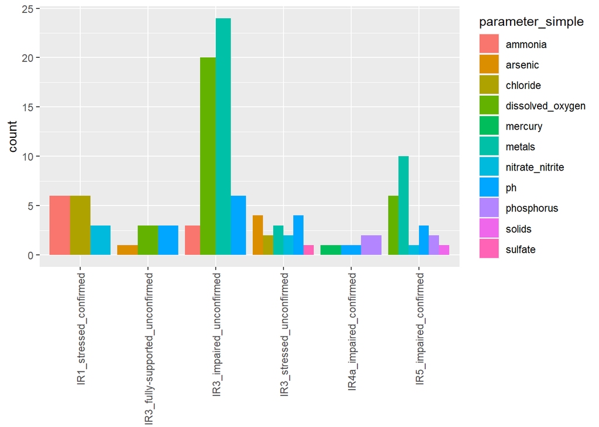

## Analysis of SDWIS Data

Should we be including NYC reservoirs? Do we assess these?

Filtered to only those that were unassessed or needed more data

Populations served (Removing NYC reservoirs)

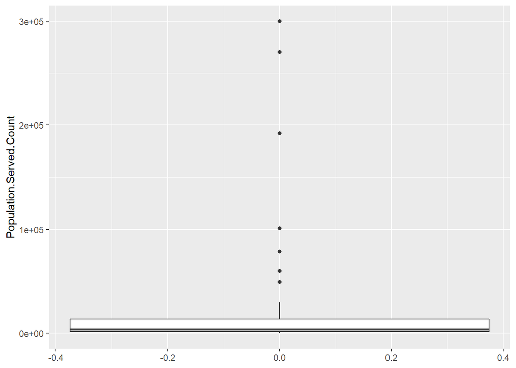

Service Connections (again removing NYC reservoirs)

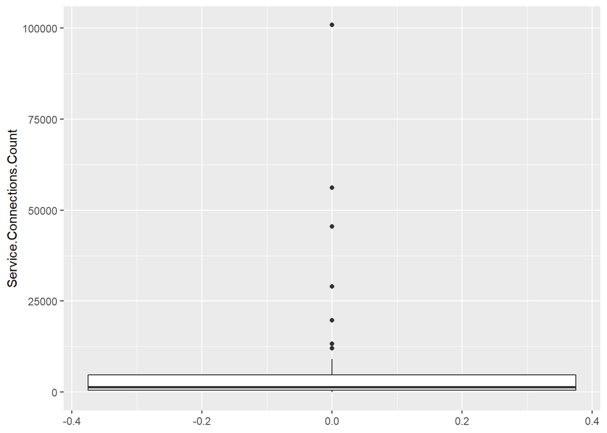

Filtration Status

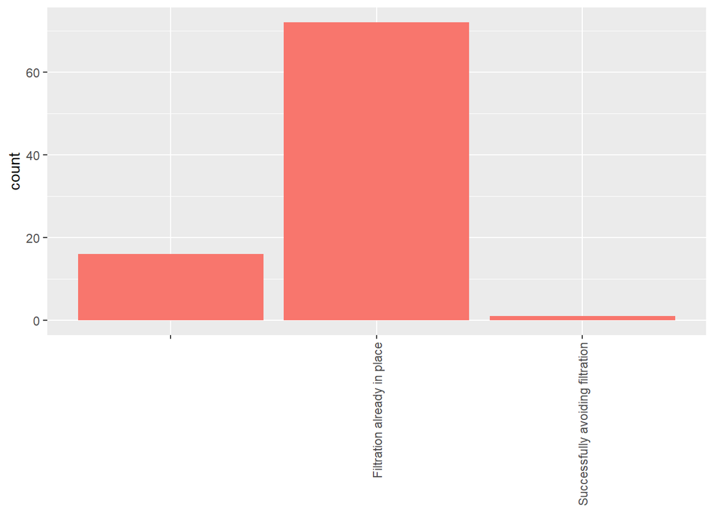

Owner Type

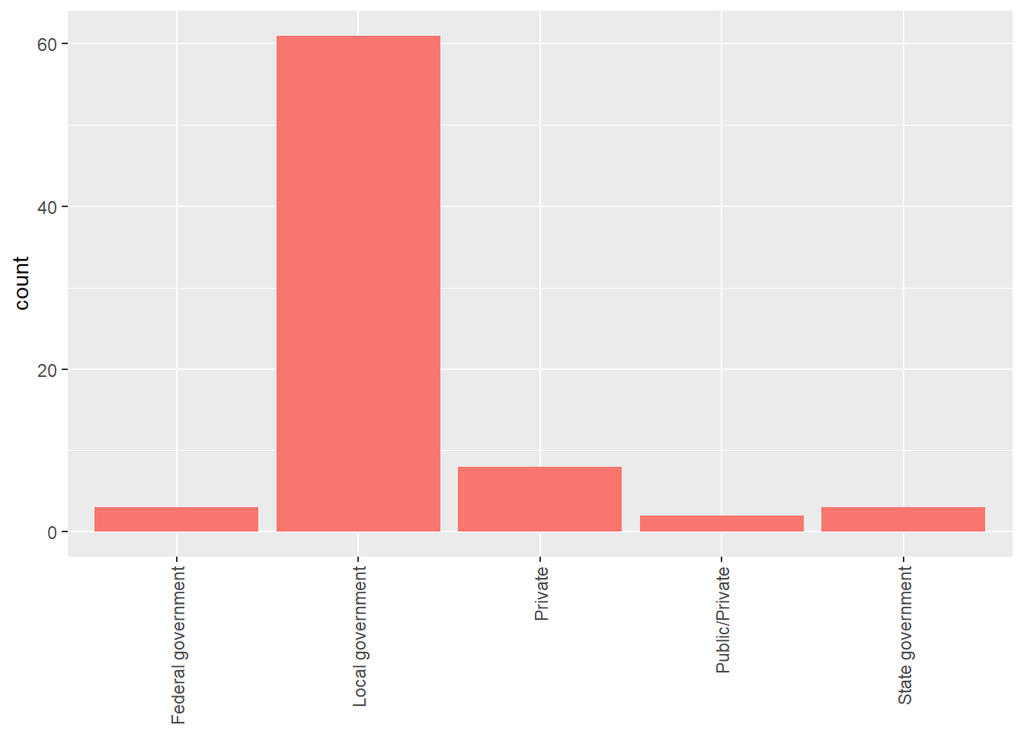

Number of Violations

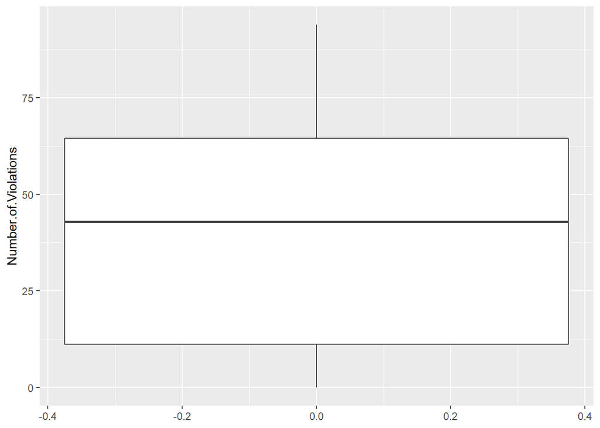